# Project 1

## Put it Together

### Read the previous two data sets and create two data frames by using the wrapper function:

```r
a<- my_wrapper("https://www4.stat.ncsu.edu/~online/datasets/EDU01a.csv")
b<- my_wrapper("https://www4.stat.ncsu.edu/~online/datasets/EDU01b.csv")
```

### Run the data combining function to create state data frame and county data frame:

```r
dat_county <- dplyr::bind_rows(a[[1]], b[[1]])
dat_non_county<- dplyr::bind_rows(a[[2]], b[[2]])
as_tibble(dat_county)
```

```
## # A tibble: 62,900 × 7
##    area_name   STCOU iterm_id   value type     year state
##    <chr>       <chr> <chr>      <dbl> <chr>   <dbl> <chr>
##  1 Autauga, AL 01001 EDU010187D  6829 EDU0101  1987 AL
##  2 Autauga, AL 01001 EDU010188D  6900 EDU0101  1988 AL
##  3 Autauga, AL 01001 EDU010189D  6920 EDU0101  1989 AL
##  4 Autauga, AL 01001 EDU010190D  6847 EDU0101  1990 AL
##  5 Autauga, AL 01001 EDU010191D  7008 EDU0101  1991 AL
##  6 Autauga, AL 01001 EDU010192D  7137 EDU0101  1992 AL
##  7 Autauga, AL 01001 EDU010193D  7152 EDU0101  1993 AL
##  8 Autauga, AL 01001 EDU010194D  7381 EDU0101  1994 AL
##  9 Autauga, AL 01001 EDU010195D  7568 EDU0101  1995 AL
## 10 Autauga, AL 01001 EDU010196D  7834 EDU0101  1996 AL
## # … with 62,890 more rows
```

```r
as_tibble(dat_non_county)
```

```
## # A tibble: 1,060 × 7
##    area_name     STCOU iterm_id      value type     year division
##    <chr>         <chr> <chr>         <dbl> <chr>   <dbl> <chr>
##  1 UNITED STATES 00000 EDU010187D 40024299 EDU0101  1987 ERROR
##  2 UNITED STATES 00000 EDU010188D 39967624 EDU0101  1988 ERROR
##  3 UNITED STATES 00000 EDU010189D 40317775 EDU0101  1989 ERROR
##  4 UNITED STATES 00000 EDU010190D 40737600 EDU0101  1990 ERROR
##  5 UNITED STATES 00000 EDU010191D 41385442 EDU0101  1991 ERROR
##  6 UNITED STATES 00000 EDU010192D 42088151 EDU0101  1992 ERROR
##  7 UNITED STATES 00000 EDU010193D 42724710 EDU0101  1993 ERROR
##  8 UNITED STATES 00000 EDU010194D 43369917 EDU0101  1994 ERROR
##  9 UNITED STATES 00000 EDU010195D 43993459 EDU0101  1995 ERROR
## 10 UNITED STATES 00000 EDU010196D 44715737 EDU0101  1996 ERROR
## # … with 1,050 more rows
```

### Use the plot function on state data frame:

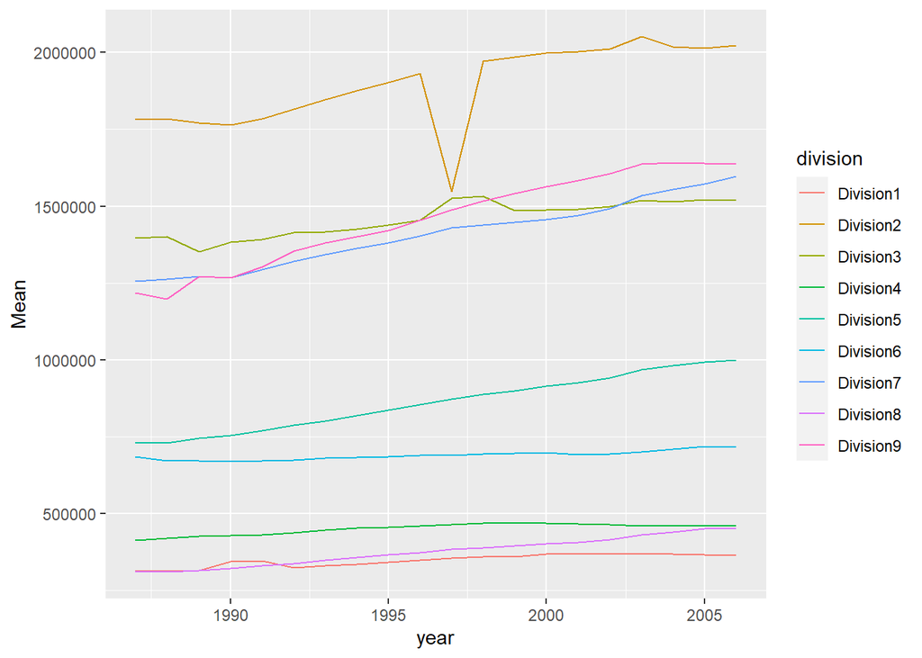

```r
plot.state(dat_non_county)
```

### Use the plot function on the county data frame:

- State to be “PA”, the group being the top, number looked at being 7:

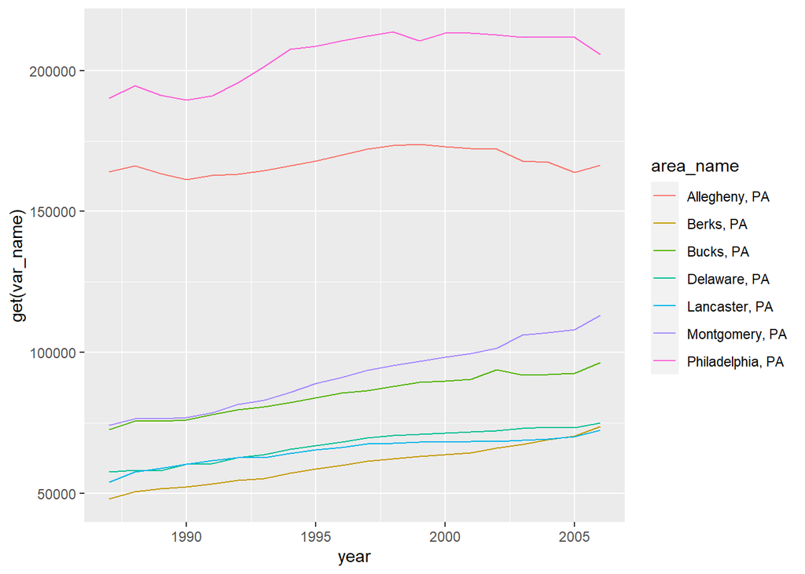

```r
plot.county(dat_county, ST="PA", order="top", x=7, var_name = "value")
```

- State to be “PA”, the group being the bottom, number looked at being 4:

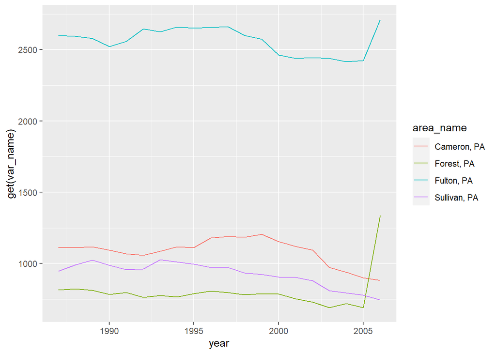

```r
plot.county(dat_county, ST="PA", order="bottom", x=4, var_name = "value")
```

- Default output for the plot function:

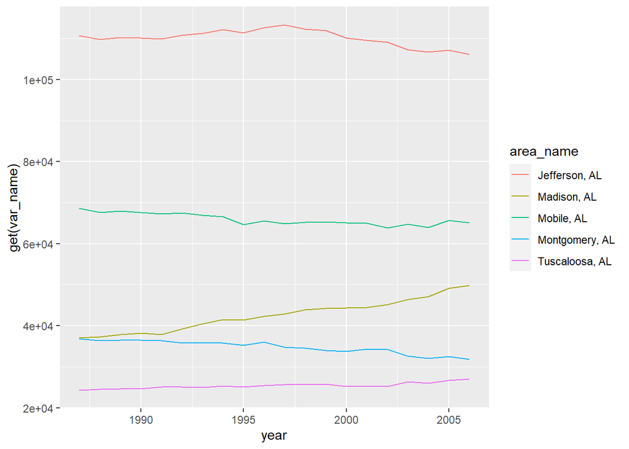

```r
plot.county(dat_county, var_name = "value")
```

- State to be “MN”, the group being the top, number looked at being 10:

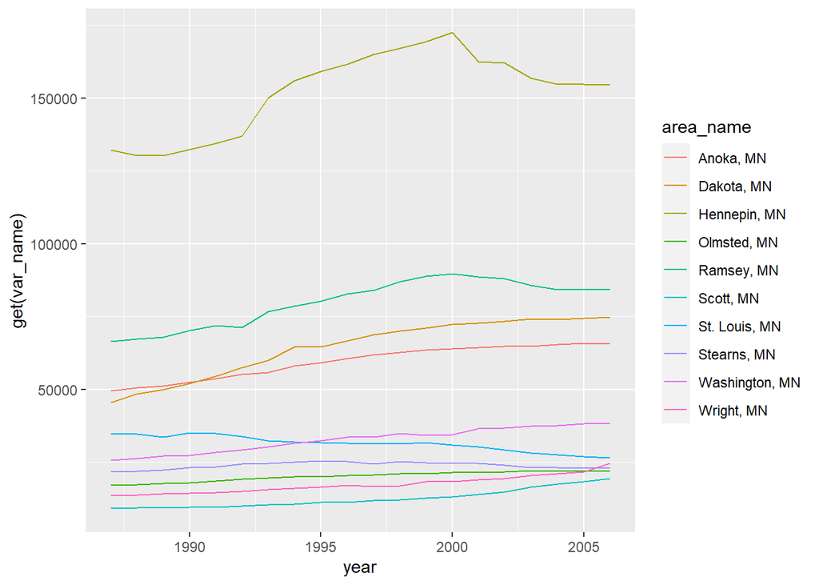

```r
plot.county(dat_county, ST="MN", order="top", x=10, var_name = "value")
```

### Run the data processing function on the four data sets below:

#### Use wrapper function to read and subset data

```r
c<- my_wrapper("https://www4.stat.ncsu.edu/~online/datasets/PST01a.csv")
d<- my_wrapper("https://www4.stat.ncsu.edu/~online/datasets/PST01b.csv")
e<- my_wrapper("https://www4.stat.ncsu.edu/~online/datasets/PST01c.csv")
f<- my_wrapper("https://www4.stat.ncsu.edu/~online/datasets/PST01d.csv")
```

#### Run the data combining function to put these into two data frames:

```r
cdef_county <- dplyr::bind_rows(c[[1]], d[[1]], e[[1]], f[[1]])
cdef_non_county<- dplyr::bind_rows(c[[2]], d[[2]], e[[2]], f[[2]])
as_tibble(cdef_county)
```

```
## # A tibble: 125,800 × 7
##    area_name   STCOU iterm_id   value type     year state
##    <chr>       <chr> <chr>      <dbl> <chr>   <dbl> <chr>
##  1 Autauga, AL 01001 PST015171D 25508 PST0151  1971 AL
##  2 Autauga, AL 01001 PST015172D 27166 PST0151  1972 AL
##  3 Autauga, AL 01001 PST015173D 28463 PST0151  1973 AL
##  4 Autauga, AL 01001 PST015174D 29266 PST0151  1974 AL
##  5 Autauga, AL 01001 PST015175D 29718 PST0151  1975 AL
##  6 Autauga, AL 01001 PST015176D 29896 PST0151  1976 AL
##  7 Autauga, AL 01001 PST015177D 30462 PST0151  1977 AL
##  8 Autauga, AL 01001 PST015178D 30882 PST0151  1978 AL
##  9 Autauga, AL 01001 PST015179D 32055 PST0151  1979 AL
## 10 Autauga, AL 01001 PST025181D 31985 PST0251  1981 AL
## # … with 125,790 more rows
```

```r
as_tibble(cdef_non_county)
```

```
## # A tibble: 2,120 × 7
##    area_name     STCOU iterm_id       value type     year division
##    <chr>         <chr> <chr>          <dbl> <chr>   <dbl> <chr>
##  1 UNITED STATES 00000 PST015171D 206827028 PST0151  1971 ERROR
##  2 UNITED STATES 00000 PST015172D 209283904 PST0151  1972 ERROR
##  3 UNITED STATES 00000 PST015173D 211357490 PST0151  1973 ERROR
##  4 UNITED STATES 00000 PST015174D 213341552 PST0151  1974 ERROR
##  5 UNITED STATES 00000 PST015175D 215465246 PST0151  1975 ERROR
##  6 UNITED STATES 00000 PST015176D 217562728 PST0151  1976 ERROR
##  7 UNITED STATES 00000 PST015177D 219759860 PST0151  1977 ERROR
##  8 UNITED STATES 00000 PST015178D 222095080 PST0151  1978 ERROR
##  9 UNITED STATES 00000 PST015179D 224567234 PST0151  1979 ERROR
## 10 UNITED STATES 00000 PST025181D 229466391 PST0251  1981 ERROR
## # … with 2,110 more rows
```

#### Use the plot function on the **state** data frame:

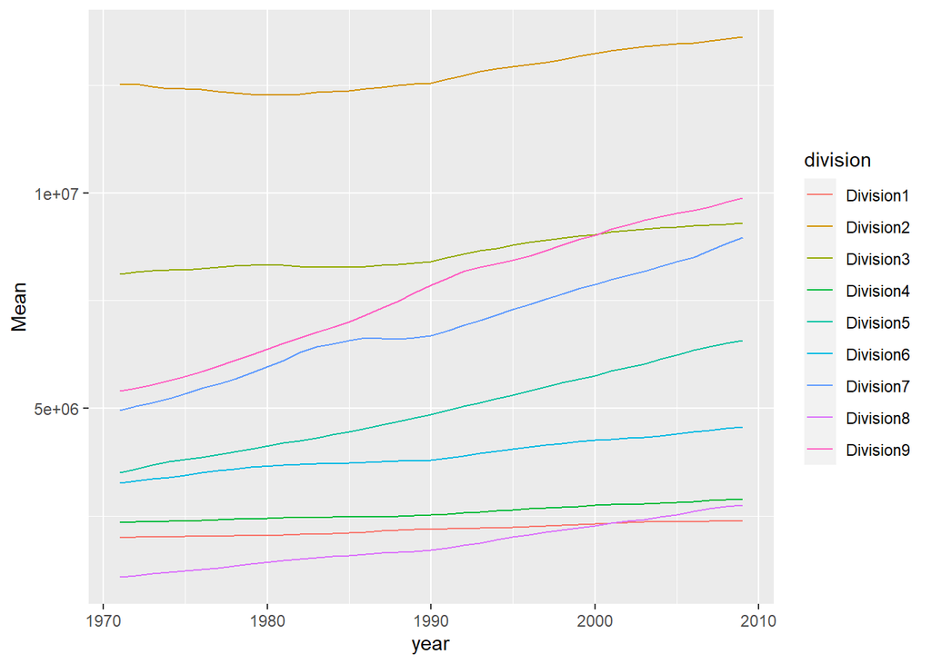

```r
plot.state(cdef_non_county)
```

#### Use the plot function on the **county** data frame:

- State to be “CT”, the group being the top, number looked at being 6:

[figure not shown]

```r
plot.county(cdef_county, ST="CT", order="top", x=6, var_name = "value")
```

- State to be “NC”, the group being the bottom, number looked at being 10:

[figure not shown]

```r
plot.county(cdef_county, ST="NC", order="bottom", x=10, var_name = "value")
```

- Default output for the plot function:

[figure not shown]

```r
plot.county(cdef_county, var_name = "value")
```

- State to be “MN”, the group being the top, number looked at being 4:

[figure not shown]

```r
plot.county(cdef_county, ST="MN", order="top", x=4, var_name = "value")
```